# Project: Investigating a dataset.

**I this notebook we will investigate The Movie Database (TMDB) provided by Udacity.**

## Table of Contents.

- Introduction.
- Gathering stuff.
- Walking through the data.
  - Basic information about the dataset.
  - Questions List.
    - Which genres are most popular?
    - What is the most popular movie each year?
    - What kinds of properties are associated with movies that have high revenues?
- Conclusions.

## Introduction.

I guess all of us like movies. Whether you're a student -like I am- or a hardworker, male, female, a partner or a parent, you probably like movies. Movies like music, has alot of genres so it satisfy most of tastes. Watch movies, watch more, ask people, much, and you'll end with your favourite kind, you'll also have an overveiw about movies, their genres, popularity, fans and much more. We'll do something similar here in this notebook. By analyzing the data from TMDB We'll end up knowing much stuff that can be helpful finding our joy, The Joy of Movies.

## Importing libraries and loading the dataset.

```python
# Using this cell to set up import statements for all of the packages, the datasets and topics that are considered to be used

import pandas as pd
import numpy as np
import matplotlib.pyplot as plt
import seaborn as sns
%matplotlib inline

df = pd.read_csv('tmdb-movies.csv')

"""Changing scientific numbers to numeric numbers"""
#https://stackoverflow.com/questions/38689125/how-to-get-rid-of-pandas-converting-large-numbers-in-excel-sheet-to-exponential
pd.options.display.float_format = '{:.2f}'.format
```

## Brief information list about our dataset:

```python
df.info()
```

```
<class 'pandas.core.frame.DataFrame'>
RangeIndex: 10866 entries, 0 to 10865
Data columns (total 21 columns):
 #   Column                Non-Null Count  Dtype
---  ------                --------------  -----
 0   id                    10866 non-null  int64
 1   imdb_id               10856 non-null  object
 2   popularity            10866 non-null  float64
 3   budget                10866 non-null  int64
 4   revenue               10866 non-null  int64
 5   original_title        10866 non-null  object
 6   cast                  10790 non-null  object
 7   homepage              2936 non-null   object
 8   director              10822 non-null  object
 9   tagline               8042 non-null   object
 10  keywords              9373 non-null   object
 11  overview              10862 non-null  object
 12  runtime               10866 non-null  int64
 13  genres                10843 non-null  object
 14  production_companies  9836 non-null   object
 15  release_date          10866 non-null  object
 16  vote_count            10866 non-null  int64
 17  vote_average          10866 non-null  float64
 18  release_year          10866 non-null  int64
 19  budget_adj            10866 non-null  float64
 20  revenue_adj           10866 non-null  float64
dtypes: float64(4), int64(6), object(11)
memory usage: 1.7+ MB
```

```python
df[['popularity', 'runtime', 'budget_adj', 'revenue_adj']].describe()
#Seems slightly off, let's clean and try again..
```

|  | popularity | runtime | budget_adj | revenue_adj |
| --- | --- | --- | --- | --- |
| count | 10866.00 | 10866.00 | 10866.00 | 10866.00 |
| mean | 0.65 | 102.07 | 17551039.82 | 51364363.25 |
| std | 1.00 | 31.38 | 34306155.72 | 144632485.04 |
| min | 0.00 | 0.00 | 0.00 | 0.00 |
| 25% | 0.21 | 90.00 | 0.00 | 0.00 |
| 50% | 0.38 | 99.00 | 0.00 | 0.00 |
| 75% | 0.71 | 111.00 | 20853251.08 | 33697095.72 |
| max | 32.99 | 900.00 | 425000000.00 | 2827123750.41 |

# Overview and Notes about the dataset:

**This data set contains information about 10,000 movies collected from The Movie Database (TMDb), including user ratings and revenue.**

- Certain columns, like ‘cast’ and ‘genres’, contain multiple values separated by pipe (|) characters.
- There are some odd characters in the ‘cast’ column. Didn’t worry about cleaning them. Just left them as they were.
- The final two columns ending with “_adj” show the budget and revenue of the associated movie in terms of 2010 dollars, accounting for inflation over time.

## Provided the data from info and describe tables we conclude that there's wrong data, cells with 'NaN' or zero values that need to be cleaned.

### Cells in budget/_adj , revenue/_adj, and runtime shall be replaced with 'NaN', then dropped.

```python
df['revenue_adj'].replace(0, np.NAN, inplace=True)
df['revenue'].replace(0, np.NAN, inplace=True)
df['budget_adj'].replace(0, np.NAN, inplace=True)
df['budget'].replace(0, np.NAN, inplace=True)
df['runtime'].replace(0, np.NAN, inplace=True)

df.dropna(axis=0, inplace=True)
```

```python
df[['popularity', 'runtime', 'budget_adj', 'revenue_adj']].describe()
```

|  | popularity | runtime | budget_adj | revenue_adj |
| --- | --- | --- | --- | --- |
| count | 1287.00 | 1287.00 | 1287.00 | 1287.00 |
| mean | 1.79 | 110.27 | 54629935.84 | 199177499.23 |
| std | 2.17 | 18.81 | 55254627.64 | 296851462.45 |
| min | 0.01 | 63.00 | 0.97 | 43.00 |
| 25% | 0.66 | 97.00 | 15191799.51 | 27648902.20 |
| 50% | 1.15 | 107.00 | 35569267.40 | 86747695.58 |
| 75% | 2.13 | 121.00 | 76301250.18 | 235117806.64 |
| max | 32.99 | 201.00 | 425000000.00 | 2827123750.41 |

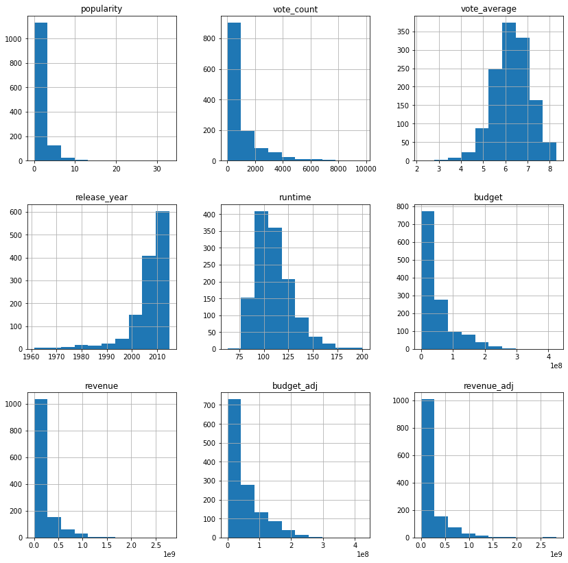

```python
df[['popularity','vote_count', 'vote_average', 'release_year', 'runtime', 'budget', 'revenue', 'budget_adj', 'revenue_adj']].hist(figsize=(14,14));
```

### The previous histograms shows interesting information, such as most of movies' estimated revenue are below 500 millions while their budget were under 100 millions.

# Questions:

- Which genres are most popular?
- What is the most popular movie each year?
- What kinds of properties are associated with movies that have high revenues?

## Here We can see some results matching popularity with genres, from which We indecate how relative a genre is to popularity.

```python
pvg = df.set_index('popularity').sort_index(axis=0, level=None, ascending=False).head(10)['genres']
pvg #popularity versus genre
```

```
popularity
32.99    Action|Adventure|Science Fiction|Thriller
28.42    Action|Adventure|Science Fiction|Thriller
24.95              Adventure|Drama|Science Fiction
14.31             Action|Science Fiction|Adventure
13.11           Adventure|Science Fiction|Thriller
12.97             Action|Adventure|Science Fiction
12.04             Adventure|Action|Science Fiction
11.42                              Action|Thriller
11.17     Action|Adventure|Science Fiction|Fantasy
10.74           Science Fiction|Adventure|Thriller
Name: genres, dtype: object
```

### Here We count how much a genre is related to the most popluar movies.

**Taking the ten most popular movies.**

- 90% Sci-Fi.
- 90% Adventure.
- 70% Action.
- 50% Thriller.
- 10% Fantasy.
- 10% Drama.

```python
def pvgf(pvg, ptype, title, xlabel, ylabel): #popularity vs genre function

    '''Takes a Series, split object by pipe (|), append the splitted items to a container to be counted.'''

    container = []
    for i in pvg:
        for j in i.split("|"):
            container.append(j)

    if ptype == "scatter":
        sns.scatterplot(data = container)
    else:
        sns.displot(container);
    plt.xticks(rotation=90);
    plt.title(title);
    plt.xlabel(xlabel);
    plt.ylabel(ylabel);
```

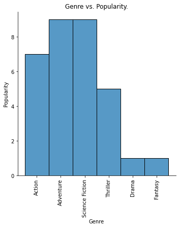

```python
pvgf(pvg,"", "Genre vs. Popularity.", "Genre", "Popularity")
```

### Here we see the most commonly liked genres, sci-fi, adventure, and action

# What's the most popular movie, year by year.

```python
mpm = pd.DataFrame(columns=['id','imdb_id','popularity','budget','revenue',
'original_title','cast','homepage','director','tagline','keywords','overview',
'runtime','genres','production_companies','release_date','vote_count',
'vote_average','release_year','budget_adj','revenue_adj']).set_index('popularity')

for i in np.sort(df['release_year'].unique()):
    mpm = pd.concat([mpm, df[df['release_year'] == i].set_index('popularity').sort_index(axis = 0, ascending = False).head(1)])

mpm #most popular movie
```

| popularity | id | imdb_id | budget | revenue | original_title | cast | homepage | director | tagline | keywords | overview | runtime | genres | production_companies | release_date | vote_count | vote_average | release_year | budget_adj | revenue_adj |
| --- | --- | --- | --- | --- | --- | --- | --- | --- | --- | --- | --- | --- | --- | --- | --- | --- | --- | --- | --- | --- |
| 0.30 | 430 | tt0055256 | 3000000.00 | 4000000.00 | One, Two, Three | James Cagney\|Liselotte Pulver\|Horst Buchholz\|P... | http://en.wikipedia.org/wiki/One,_Two,_Three | Billy Wilder | Billy Wilder's Explosive New Comedy | berlin\|prison\|clerk\|atlanta\|cold war | One, Two, Three – A scorching business comed... | 115.00 | Comedy\|Family | The Mirisch Corporation | 12/15/61 | 30 | 7.50 | 1961 | 21884583.62 | 29179444.83 |
| 3.17 | 646 | tt0055928 | 1100000.00 | 59600000.00 | Dr. No | Sean Connery\|Ursula Andress\|Joseph Wiseman\|Jac... | http://www.mgm.com/view/movie/566/Dr.-No/ | Terence Young | NOW meet the most extraordinary gentleman spy ... | london\|england\|assassination\|spy\|casino | In the film that launched the James Bond saga,... | 110.00 | Adventure\|Action\|Thriller | Eon Productions\|Metro-Goldwyn-Mayer (MGM) | 10/4/62 | 560 | 6.70 | 1962 | 7929293.77 | 429623553.17 |
| 2.51 | 657 | tt0057076 | 2500000.00 | 78898765.00 | From Russia With Love | Sean Connery\|Daniela Bianchi\|Lotte Lenya\|Rober... | http://www.mgm.com/view/movie/717/From-Russia-... | Terence Young | The world's masters of murder pull out all the... | venice\|london\|terror\|england\|assassination | Agent 007 is back in the second installment of... | 115.00 | Action\|Thriller\|Adventure | Eon Productions\|Metro-Goldwyn-Mayer (MGM)\|Danjaq | 10/11/63 | 458 | 6.70 | 1963 | 17800448.43 | 561773358.99 |
| 3.15 | 658 | tt0058150 | 3500000.00 | 124900000.00 | Goldfinger | Sean Connery\|Honor Blackman\|Gert Fröbe\|Shirle... | http://www.mgm.com/view/movie/760/Goldfinger/ | Guy Hamilton | Everything he touches turns into excitement! | secret organization\|secret intelligence servic... | Special agent 007 (Sean Connery) comes face to... | 110.00 | Adventure\|Action\|Thriller | Eon Productions\|Metro-Goldwyn-Mayer (MGM) | 9/17/64 | 602 | 7.00 | 1964 | 24605935.94 | 878080399.54 |
| 1.91 | 660 | tt0059800 | 11000000.00 | 141195658.00 | Thunderball | Sean Connery\|Claudine Auger\|Adolfo Celi\|Lucian... | http://www.mgm.com/view/movie/2009/Thunderball/ | Terence Young | Look up! Look down! Look out! | paris\|florida\|fighter pilot\|sanatorium\|secret ... | A criminal organization has obtained two nucle... | 130.00 | Adventure\|Action\|Thriller | Eon Productions\|Metro-Goldwyn-Mayer (MGM) | 12/16/65 | 331 | 6.30 | 1965 | 76126200.63 | 977153544.47 |
| 1.55 | 667 | tt0062512 | 9500000.00 | 111584787.00 | You Only Live Twice | Sean Connery\|Akiko Wakabayashi\|Karin Dor\|Mie H... | http://www.mgm.com/view/movie/2347/You-Only-Li... | Lewis Gilbert | You Only Live Twice...and Twice is the only wa... | london\|japan\|england\|assassination\|helicopter | A mysterious space craft kidnaps a Russian and... | 117.00 | Action\|Thriller\|Adventure | Eon Productions | 6/12/67 | 301 | 6.20 | 1967 | 62099255.53 | 729403389.57 |
| 1.78 | 668 | tt0064757 | 7000000.00 | 81974493.00 | On Her Majesty's Secret Service | George Lazenby\|Diana Rigg\|Telly Savalas\|Gabrie... | http://www.mgm.com/view/movie/1411/On-Her-Maje... | Peter R. Hunt | Far up! Far out! Far more! James Bond 007 is b... | london\|suicide\|england\|switzerland\|secret iden... | James Bond tracks archnemesis Ernst Blofeld to... | 142.00 | Adventure\|Action\|Thriller | Eon Productions\|Metro-Goldwyn-Mayer (MGM)\|Danjaq | 12/12/69 | 258 | 6.40 | 1969 | 41609849.41 | 487278044.15 |
| 1.76 | 681 | tt0066995 | 7200000.00 | 116000000.00 | Diamonds Are Forever | Sean Connery\|Jill St. John\|Charles Gray\|Lana W... | http://www.mgm.com/view/movie/529/Diamonds-Are... | Guy Hamilton | The man who made 007 a household number | satellite\|plastic surgery\|smuggling\|murder\|ext... | Diamonds are stolen only to be sold again in t... | 120.00 | Adventure\|Action\|Thriller\|Science Fiction | Eon Productions\|Metro-Goldwyn-Mayer (MGM)\|Danjaq | 12/13/71 | 331 | 6.20 | 1971 | 38773403.38 | 624682610.07 |
| 5.74 | 238 | tt0068646 | 6000000.00 | 245066411.00 | The Godfather | Marlon Brando\|Al Pacino\|James Caan\|Richard S. ... | http://www.thegodfather.com/ | Francis Ford Coppola | An offer you can't refuse. | italy\|love at first sight\|loss of father\|patri... | Spanning the years 1945 to 1955, a chronicle o... | 175.00 | Drama\|Crime | Paramount Pictures\|Alfran Productions | 3/15/72 | 3970 | 8.30 | 1972 | 31287365.59 | 1277913732.39 |
| 2.01 | 9552 | tt0070047 | 8000000.00 | 441306145.00 | The Exorcist | Linda Blair\|Max von Sydow\|Ellen Burstyn\|Jason ... | http://theexorcist.warnerbros.com/ | William Friedkin | Something almost beyond comprehension is happe... | exorcism\|holy water\|religion and supernatural\|... | 12-year-old Regan MacNeil begins to adapt an e... | 122.00 | Drama\|Horror\|Thriller | Warner Bros.\|Hoya Productions | 12/26/73 | 1113 | 7.20 | 1973 | 39289276.63 | 2167324901.20 |
| 1.62 | 682 | tt0071807 | 7000000.00 | 97572000.00 | The Man with the Golden Gun | Roger Moore\|Christopher Lee\|Britt Ekland\|Maud ... | http://www.mgm.com/view/movie/1213/The-Man-wit... | Guy Hamilton | The man with the golden gun is ready to assass... | london\|england\|martial arts\|assassin\|exotic is... | A golden bullet has 007 engraved on it as it s... | 125.00 | Adventure\|Action\|Thriller | Eon Productions\|Metro-Goldwyn-Mayer (MGM)\|Danjaq | 12/1/74 | 283 | 6.10 | 1974 | 30955987.22 | 431491083.57 |
| 2.56 | 578 | tt0073195 | 7000000.00 | 470654000.00 | Jaws | Roy Scheider\|Robert Shaw\|Richard Dreyfuss\|Lorr... | http://www.jaws25.com/ | Steven Spielberg | Don't go in the water. | fishing\|atlantic ocean\|bathing\|shipwreck\|polic... | An insatiable great white shark terrorizes the... | 124.00 | Horror\|Thriller\|Adventure | Universal Pictures\|Zanuck/Brown Productions | 6/18/75 | 1415 | 7.30 | 1975 | 28362748.20 | 1907005841.92 |
| 12.04 | 11 | tt0076759 | 11000000.00 | 775398007.00 | Star Wars | Mark Hamill\|Harrison Ford\|Carrie Fisher\|Peter ... | http://www.starwars.com/films/star-wars-episod... | George Lucas | A long time ago in a galaxy far, far away... | android\|galaxy\|hermit\|death star\|lightsaber | Princess Leia is captured and held hostage by ... | 121.00 | Adventure\|Action\|Science Fiction | Lucasfilm\|Twentieth Century Fox Film Corporation | 3/20/77 | 4428 | 7.90 | 1977 | 39575591.36 | 2789712242.28 |
| 1.20 | 948 | tt0077651 | 300000.00 | 70000000.00 | Halloween | Donald Pleasence\|Jamie Lee Curtis\|P.J. Soles\|N... | http://www.theofficialjohncarpenter.com/hallow... | John Carpenter | The Night HE Came Home! | female nudity\|nudity\|mask\|babysitter\|halloween | A psychotic murderer, institutionalized since ... | 91.00 | Horror\|Thriller | Compass International Pictures\|Falcon Internat... | 10/25/78 | 522 | 7.30 | 1978 | 1002810.21 | 233989048.64 |
| 4.94 | 348 | tt0078748 | 11000000.00 | 104931801.00 | Alien | Sigourney Weaver\|Tom Skerritt\|Veronica Cartwri... | https://www.facebook.com/alienanthology/ | Ridley Scott | In space no one can hear you scream. | android\|self-destruction\|countdown\|space marin... | During its return to the earth, commercial spa... | 117.00 | Horror\|Action\|Thriller\|Science Fiction | Twentieth Century-Fox Productions\|Brandywine P... | 5/25/79 | 2724 | 7.60 | 1979 | 33050094.03 | 315273262.68 |
| 5.49 | 1891 | tt0080684 | 18000000.00 | 538400000.00 | The Empire Strikes Back | Mark Hamill\|Harrison Ford\|Carrie Fisher\|Billy ... | http://www.starwars.com/films/star-wars-episod... | Irvin Kershner | The Adventure Continues... | rebel\|asteroid\|space battle\|snow storm\|space c... | The epic saga continues as Luke Skywalker, in ... | 124.00 | Adventure\|Action\|Science Fiction | Lucasfilm\|Twentieth Century Fox Film Corporation | 1/1/80 | 3954 | 8.00 | 1980 | 47628661.55 | 1424626187.77 |
| 4.58 | 85 | tt0082971 | 18000000.00 | 389925971.00 | Raiders of the Lost Ark | Harrison Ford\|Karen Allen\|Paul Freeman\|Ronald ... | http://www.indianajones.com | Steven Spielberg | Indiana Jones - the new hero from the creators... | saving the world\|riddle\|nepal\|himalaya\|cairo | When Dr. Indiana Jones – the tweed-suited pr... | 115.00 | Adventure\|Action | Lucasfilm\|Paramount Pictures | 6/12/81 | 2506 | 7.50 | 1981 | 43167434.49 | 935116878.23 |
| 4.22 | 78 | tt0083658 | 28000000.00 | 32768670.00 | Blade Runner | Harrison Ford\|Rutger Hauer\|Sean Young\|Edward J... | http://www.warnerbros.com/blade-runner | Ridley Scott | Man has made his match... now it's his problem. | artificial intelligence\|man vs machine\|cyborg\|... | In the smog-choked dystopian Los Angeles of 20... | 117.00 | Science Fiction\|Drama\|Thriller | Shaw Brothers\|Warner Bros.\|The Ladd Company | 6/25/82 | 2110 | 7.70 | 1982 | 63269987.27 | 74045476.21 |
| 4.83 | 1892 | tt0086190 | 32350000.00 | 572700000.00 | Return of the Jedi | Mark Hamill\|Harrison Ford\|Carrie Fisher\|Billy ... | http://www.starwars.com/films/star-wars-episod... | Richard Marquand | The Empire Falls... | rebel\|emperor\|space battle\|matter of life and ... | As Rebel leaders map their strategy for an all... | 135.00 | Adventure\|Action\|Science Fiction | Lucasfilm\|Twentieth Century Fox Film Corporation | 5/23/83 | 3101 | 7.80 | 1983 | 70824243.13 | 1253818981.12 |
| 4.83 | 218 | tt0088247 | 6400000.00 | 78371200.00 | The Terminator | Arnold Schwarzenegger\|Michael Biehn\|Linda Hami... | http://www.mgm.com/#/our-titles/1970/The-Termi... | James Cameron | Your future is in his hands. | saving the world\|artificial intelligence\|rebel... | In the post-apocalyptic future, reigning tyran... | 108.00 | Action\|Thriller\|Science Fiction | Orion Pictures\|Pacific Western\|Hemdale Film\|Ci... | 10/26/84 | 2692 | 7.10 | 1984 | 13433869.05 | 164504443.46 |
| 6.10 | 105 | tt0088763 | 19000000.00 | 381109762.00 | Back to the Future | Michael J. Fox\|Christopher Lloyd\|Lea Thompson\|... | http://www.backtothefuture.com/movies/backtoth... | Robert Zemeckis | He's the only kid ever to get into trouble bef... | clock tower\|car race\|terrorist\|delorean\|lightning | Eighties teenager Marty McFly is accidentally ... | 116.00 | Adventure\|Comedy\|Science Fiction\|Family | Universal Pictures\|Amblin Entertainment\|U-Driv... | 7/3/85 | 3785 | 7.80 | 1985 | 38516154.99 | 772572771.71 |
| 0.96 | 6978 | tt0090728 | 25000000.00 | 11000000.00 | Big Trouble in Little China | Kurt Russell\|Kim Cattrall\|Dennis Dun\|James Hon... | http://www.theofficialjohncarpenter.com/big-tr... | John Carpenter | Adventure doesn't come any bigger! | kung fu\|chinatown\|magic | When trucker Jack Burton agreed to take his fr... | 99.00 | Adventure\|Fantasy\|Action\|Comedy | Twentieth Century Fox Film Corporation\|TAFT En... | 5/30/86 | 347 | 6.70 | 1986 | 49735160.27 | 21883470.52 |
| 1.95 | 88 | tt0092890 | 6000000.00 | 213954274.00 | Dirty Dancing | Jennifer Grey\|Patrick Swayze\|Jerry Orbach\|Cynt... | http://lionsgateathome.com/dirty-dancing | Emile Ardolino | Have the time of your life. | dancing\|sex\|hotel\|robbery\|sister sister relati... | Expecting the usual tedium that accompanies a ... | 100.00 | Drama\|Music\|Romance | Great American Films Limited Partnership\|Vestr... | 8/21/87 | 654 | 6.90 | 1987 | 11514482.63 | 410595461.87 |
| 0.54 | 8337 | tt0096256 | 4000000.00 | 13008928.00 | They Live | Roddy Piper\|Keith David\|Meg Foster\|George Buck... | http://www.theofficialjohncarpenter.com/they-l... | John Carpenter | Who are they? And what do they want? | dystopia\|social commentary\|alien invasion\|sung... | Nada, a down-on-his-luck construction worker, ... | 94.00 | Action\|Horror\|Science Fiction\|Thriller | Universal Pictures\|Alive Films\|Larry Franco Pr... | 11/23/88 | 229 | 6.90 | 1988 | 7375564.09 | 23987045.56 |
| 3.54 | 89 | tt0097576 | 48000000.00 | 474171806.00 | Indiana Jones and the Last Crusade | Harrison Ford\|Sean Connery\|Denholm Elliott\|Ali... | http://www.indianajones.com/crusade | Steven Spielberg | The man with the hat is back. And this time, h... | saving the world\|venice\|holy grail\|library\|riddle | When Dr. Henry Jones Sr. suddenly goes missing... | 127.00 | Adventure\|Action | Lucasfilm\|Paramount Pictures | 5/24/89 | 2031 | 7.40 | 1989 | 84431277.07 | 834061065.27 |
| 2.44 | 196 | tt0099088 | 40000000.00 | 244527583.00 | Back to the Future Part III | Michael J. Fox\|Christopher Lloyd\|Mary Steenbur... | http://www.backtothefuture.com/movies/backtoth... | Robert Zemeckis | They've saved the best trip for last... But th... | jules verne\|railroad robber\|california\|car rac... | The final installment of the Back to the Futur... | 118.00 | Adventure\|Action\|Comedy\|Science Fiction\|Family | Universal Pictures\|Amblin Entertainment\|U-Driv... | 5/25/90 | 1762 | 6.90 | 1990 | 66755941.61 | 408091726.34 |
| 3.85 | 10020 | tt0101414 | 25000000.00 | 377350553.00 | Beauty and the Beast | Paige O'Hara\|Robby Benson\|Richard White\|Jerry ... | http://disney.go.com/disneyvideos/animatedfilm... | Gary Trousdale\|Kirk Wise | The most beautiful love story ever told. | prince\|book\|castle\|rose\|musical | Follow the adventures of Belle, a bright young... | 84.00 | Romance\|Family\|Animation\|Fantasy\|Music | Walt Disney Pictures\|Walt Disney Animation Stu... | 11/12/91 | 1703 | 7.30 | 1991 | 40027321.05 | 604173269.31 |
| 3.97 | 812 | tt0103639 | 28000000.00 | 504050219.00 | Aladdin | Scott Weinger\|Robin Williams\|Linda Larkin\|Jona... | http://movies.disney.com/aladdin | Ron Clements\|John Musker | Wish granted! | magic\|musical\|cartoon\|princess\|love | Princess Jasmine grows tired of being forced t... | 90.00 | Animation\|Family\|Comedy\|Adventure\|Fantasy | Walt Disney Pictures | 11/25/92 | 2121 | 7.30 | 1992 | 43512679.13 | 783306265.86 |
| 2.38 | 424 | tt0108052 | 22000000.00 | 321265768.00 | Schindler's List | Liam Neeson\|Ben Kingsley\|Ralph Fiennes\|Carolin... | http://www.schindlerslist.com/ | Steven Spielberg | Whoever saves one life, saves the world entire. | factory\|concentration camp\|hero\|holocaust\|worl... | The true story of how businessman Oskar Schind... | 195.00 | Drama\|History\|War | Universal Pictures\|Amblin Entertainment | 11/29/93 | 2632 | 8.10 | 1993 | 33208339.16 | 484941026.52 |
| 4.78 | 8587 | tt0110357 | 45000000.00 | 788241776.00 | The Lion King | Jonathan Taylor Thomas\|Matthew Broderick\|James... | http://movies.disney.com/the-lion-king | Roger Allers\|Rob Minkoff | Life's greatest adventure is finding your plac... | loss of parents\|wild boar\|uncle\|shaman\|redemption | A young lion cub named Simba can't wait to be ... | 89.00 | Family\|Animation\|Drama | Walt Disney Pictures\|Walt Disney Feature Anima... | 6/23/94 | 3489 | 7.70 | 1994 | 66200020.27 | 1159591590.01 |
| 4.77 | 807 | tt0114369 | 33000000.00 | 327311859.00 | Se7en | Brad Pitt\|Morgan Freeman\|Gwyneth Paltrow\|John ... | http://www.sevenmovie.com/ | David Fincher | Seven deadly sins. Seven ways to die. | self-fulfilling prophecy\|detective\|s.w.a.t.\|dr... | Two homicide detectives are on a desperate hun... | 127.00 | Crime\|Mystery\|Thriller | New Line Cinema\|Juno Pix\|Cecchi Gori Pictures | 9/22/95 | 3535 | 7.90 | 1995 | 47221906.61 | 468372425.44 |
| 3.29 | 954 | tt0117060 | 80000000.00 | 457696359.00 | Mission: Impossible | Tom Cruise\|Jon Voight\|Emmanuelle Béart\|Henry ... | http://www.missionimpossible.com/ | Brian De Palma | Expect the Impossible. | paris\|london\|cia\|terrorist\|secret identity | When Ethan Hunt, the leader of a crack espiona... | 110.00 | Adventure\|Action\|Thriller | Paramount Pictures\|Cruise/Wagner Productions | 5/21/96 | 1754 | 6.50 | 1996 | 111217339.12 | 636297139.64 |
| 4.36 | 597 | tt0120338 | 200000000.00 | 1845034188.00 | Titanic | Kate Winslet\|Leonardo DiCaprio\|Frances Fisher\|... | http://www.titanicmovie.com/menu.html | James Cameron | Nothing on Earth could come between them. | shipwreck\|iceberg\|ship\|panic\|titanic | 84 years later, a 101-year-old woman named Ros... | 194.00 | Drama\|Romance\|Thriller | Paramount Pictures\|Twentieth Century Fox Film ... | 11/18/97 | 4654 | 7.30 | 1997 | 271692064.21 | 2506405735.42 |
| 2.73 | 36647 | tt0120611 | 45000000.00 | 131183530.00 | Blade | Wesley Snipes\|Stephen Dorff\|Kris Kristofferson... | http://www.warnerbros.com/blade | Stephen Norrington | Part Man. Part Vampire. All Hero. | suicide\|hero\|vampire\|fistfight\|supernatural | When Blade's mother was bitten by a vampire du... | 120.00 | Horror\|Action | New Line Cinema\|Amen Ra Films\|Imaginary Forces... | 8/21/98 | 1263 | 6.30 | 1998 | 60196296.11 | 175483613.70 |
| 8.95 | 550 | tt0137523 | 63000000.00 | 100853753.00 | Fight Club | Edward Norton\|Brad Pitt\|Meat Loaf\|Jared Leto\|H... | http://www.foxmovies.com/movies/fight-club | David Fincher | How much can you know about yourself if you've... | support group\|dual identity\|nihilism\|rage and ... | A ticking-time-bomb insomniac and a slippery s... | 139.00 | Drama | Regency Enterprises\|Fox 2000 Pictures\|Taurus F... | 10/14/99 | 5923 | 8.10 | 1999 | 82470329.34 | 132022892.45 |
| 3.10 | 77 | tt0209144 | 9000000.00 | 39723096.00 | Memento | Guy Pearce\|Carrie-Anne Moss\|Joe Pantoliano\|Mar... | http://www.otnemem.com/ | Christopher Nolan | Some memories are best forgotten. | individual\|insulin\|tattoo\|waitress\|amnesia | Suffering short-term memory loss after a head ... | 113.00 | Mystery\|Thriller | Summit Entertainment\|Newmarket Capital Group\|T... | 10/11/00 | 2144 | 7.90 | 2000 | 11396629.03 | 50301043.22 |
| 8.58 | 120 | tt0120737 | 93000000.00 | 871368364.00 | The Lord of the Rings: The Fellowship of the Ring | Elijah Wood\|Ian McKellen\|Viggo Mortensen\|Liv T... | http://www.lordoftherings.net/ | Peter Jackson | One ring to rule them all | elves\|dwarves\|orcs\|middle-earth (tolkien)\|hobbits | Young hobbit Frodo Baggins, after inheriting a... | 178.00 | Adventure\|Fantasy\|Action | WingNut Films\|New Line Cinema\|The Saul Zaentz ... | 12/18/01 | 6079 | 7.80 | 2001 | 114528394.85 | 1073079785.53 |
| 8.10 | 121 | tt0167261 | 79000000.00 | 926287400.00 | The Lord of the Rings: The Two Towers | Elijah Wood\|Ian McKellen\|Viggo Mortensen\|Liv T... | http://www.lordoftherings.net/ | Peter Jackson | A New Power Is Rising. | elves\|orcs\|middle-earth (tolkien)\|hobbits\|base... | Frodo and Sam are trekking to Mordor to destro... | 179.00 | Adventure\|Fantasy\|Action | WingNut Films\|New Line Cinema\|The Saul Zaentz ... | 12/18/02 | 5114 | 7.80 | 2002 | 95768650.10 | 1122902454.42 |
| 7.12 | 122 | tt0167260 | 94000000.00 | 1118888979.00 | The Lord of the Rings: The Return of the King | Elijah Wood\|Ian McKellen\|Viggo Mortensen\|Liv T... | http://www.lordoftherings.net | Peter Jackson | The eye of the enemy is moving. | elves\|orcs\|middle-earth (tolkien)\|based on nov... | Aragorn is revealed as the heir to the ancient... | 201.00 | Adventure\|Fantasy\|Action | WingNut Films\|New Line Cinema | 12/1/03 | 5636 | 7.90 | 2003 | 111423148.61 | 1326278010.48 |
| 3.86 | 38 | tt0338013 | 20000000.00 | 72258126.00 | Eternal Sunshine of the Spotless Mind | Jim Carrey\|Kate Winslet\|Elijah Wood\|Mark Ruffa... | http://www.eternalsunshine.com | Michel Gondry | I already forget how I used to feel about you. | deja vu\|lovesickness\|jealousy\|amnesia\|loss of ... | Joel Barish, heartbroken that his girlfriend u... | 108.00 | Science Fiction\|Drama\|Romance | Anonymous Content\|This Is That Productions\|Foc... | 3/19/04 | 2012 | 7.80 | 2004 | 23088908.00 | 83418061.16 |
| 5.94 | 674 | tt0330373 | 150000000.00 | 895921036.00 | Harry Potter and the Goblet of Fire | Daniel Radcliffe\|Rupert Grint\|Emma Watson\|Ralp... | http://harrypotter.warnerbros.com/ | Mike Newell | Dark And Difficult Times Lie Ahead. | diving\|library\|flying\|fireworks\|cutting the cord | Harry starts his fourth year at Hogwarts, comp... | 157.00 | Adventure\|Fantasy\|Family | Patalex IV Productions Limited\|Warner Bros.\|He... | 11/5/05 | 3406 | 7.30 | 2005 | 167484493.45 | 1000352539.23 |
| 5.84 | 834 | tt0401855 | 50000000.00 | 111340801.00 | Underworld: Evolution | Kate Beckinsale\|Scott Speedman\|Tony Curran\|Sha... | http://www.sonypictures.com/movies/underworlda... | Len Wiseman | My God. Brother, what have you done? | budapest\|key\|light\|werewolf\|evolution | As the war between the vampires and the Lycans... | 106.00 | Fantasy\|Action\|Science Fiction\|Thriller | Lakeshore Entertainment\|Screen Gems | 1/12/06 | 1015 | 6.30 | 2006 | 54083457.91 | 120433910.50 |
| 4.97 | 285 | tt0449088 | 300000000.00 | 961000000.00 | Pirates of the Caribbean: At World's End | Johnny Depp\|Orlando Bloom\|Keira Knightley\|Geof... | http://disney.go.com/disneypictures/pirates/ | Gore Verbinski | At the end of the world, the adventure begins. | ocean\|drug abuse\|exotic island\|east india trad... | Captain Barbossa, long believed to be dead, ha... | 169.00 | Adventure\|Fantasy\|Action | Walt Disney Pictures\|Jerry Bruckheimer Films\|S... | 5/19/07 | 2626 | 6.80 | 2007 | 315500574.79 | 1010653507.91 |
| 8.47 | 155 | tt0468569 | 185000000.00 | 1001921825.00 | The Dark Knight | Christian Bale\|Michael Caine\|Heath Ledger\|Aaro... | http://thedarkknight.warnerbros.com/dvdsite/ | Christopher Nolan | Why So Serious? | dc comics\|crime fighter\|secret identity\|scarec... | Batman raises the stakes in his war on crime. ... | 152.00 | Drama\|Action\|Crime\|Thriller | DC Comics\|Legendary Pictures\|Warner Bros.\|Syncopy | 7/16/08 | 8432 | 8.10 | 2008 | 187365527.25 | 1014733032.48 |
| 9.43 | 19995 | tt0499549 | 237000000.00 | 2781505847.00 | Avatar | Sam Worthington\|Zoe Saldana\|Sigourney Weaver\|S... | http://www.avatarmovie.com/ | James Cameron | Enter the World of Pandora. | culture clash\|future\|space war\|space colony\|so... | In the 22nd century, a paraplegic Marine is di... | 162.00 | Action\|Adventure\|Fantasy\|Science Fiction | Ingenious Film Partners\|Twentieth Century Fox ... | 12/10/09 | 8458 | 7.10 | 2009 | 240886902.89 | 2827123750.41 |
| 9.36 | 27205 | tt1375666 | 160000000.00 | 825500000.00 | Inception | Leonardo DiCaprio\|Joseph Gordon-Levitt\|Ellen P... | http://inceptionmovie.warnerbros.com/ | Christopher Nolan | Your mind is the scene of the crime. | loss of lover\|dream\|sleep\|subconsciousness\|heist | Cobb, a skilled thief who commits corporate es... | 148.00 | Action\|Thriller\|Science Fiction\|Mystery\|Adventure | Legendary Pictures\|Warner Bros.\|Syncopy | 7/14/10 | 9767 | 7.90 | 2010 | 160000000.00 | 825500000.00 |
| 7.96 | 1771 | tt0458339 | 140000000.00 | 370569774.00 | Captain America: The First Avenger | Chris Evans\|Hugo Weaving\|Tommy Lee Jones\|Hayle... | http://captainamerica.marvel.com/ | Joe Johnston | When patriots become heroes | new york\|usa\|world war ii\|nazis\|marvel comic | Predominantly set during World War II, Steve R... | 124.00 | Action\|Adventure\|Science Fiction | Marvel Studios | 7/22/11 | 5025 | 6.50 | 2011 | 135715725.96 | 359229613.56 |
| 7.64 | 24428 | tt0848228 | 220000000.00 | 1519557910.00 | The Avengers | Robert Downey Jr.\|Chris Evans\|Mark Ruffalo\|Chr... | http://marvel.com/avengers_movie/ | Joss Whedon | Some assembly required. | new york\|shield\|marvel comic\|comic\|superhero | When an unexpected enemy emerges and threatens... | 143.00 | Science Fiction\|Action\|Adventure | Marvel Studios | 4/25/12 | 8903 | 7.30 | 2012 | 208943741.90 | 1443191435.21 |
| 6.11 | 109445 | tt2294629 | 150000000.00 | 1274219009.00 | Frozen | Kristen Bell\|Idina Menzel\|Jonathan Groff\|Josh ... | http://movies.disney.com/frozen | Chris Buck\|Jennifer Lee | Only the act of true love will thaw a frozen h... | queen\|musical\|princess\|betrayal\|snowman | Young princess Anna of Arendelle dreams about ... | 102.00 | Animation\|Adventure\|Family | Walt Disney Pictures\|Walt Disney Animation Stu... | 11/27/13 | 3369 | 7.50 | 2013 | 140405002.91 | 1192711491.12 |
| 24.95 | 157336 | tt0816692 | 165000000.00 | 621752480.00 | Interstellar | Matthew McConaughey\|Jessica Chastain\|Anne Hath... | http://www.interstellarmovie.net/ | Christopher Nolan | Mankind was born on Earth. It was never meant ... | saving the world\|artificial intelligence\|fathe... | Interstellar chronicles the adventures of a gr... | 169.00 | Adventure\|Drama\|Science Fiction | Paramount Pictures\|Legendary Pictures\|Warner B... | 11/5/14 | 6498 | 8.00 | 2014 | 151980023.38 | 572690645.12 |
| 32.99 | 135397 | tt0369610 | 150000000.00 | 1513528810.00 | Jurassic World | Chris Pratt\|Bryce Dallas Howard\|Irrfan Khan\|Vi... | http://www.jurassicworld.com/ | Colin Trevorrow | The park is open. | monster\|dna\|tyrannosaurus rex\|velociraptor\|island | Twenty-two years after the events of Jurassic ... | 124.00 | Action\|Adventure\|Science Fiction\|Thriller | Universal Studios\|Amblin Entertainment\|Legenda... | 6/9/15 | 5562 | 6.50 | 2015 | 137999939.28 | 1392445892.52 |

# Properties associated with high revenue movies.

**Taking Inflation into Account**

### Top 10 movies with highest revenue.

```python
rrdf = df.set_index('revenue_adj').sort_index(axis=0, level=None, ascending=False).head(10)
rrdf #revenue related dataframe
```

| revenue_adj | id | imdb_id | popularity | budget | revenue | original_title | cast | homepage | director | tagline | keywords | overview | runtime | genres | production_companies | release_date | vote_count | vote_average | release_year | budget_adj |
| --- | --- | --- | --- | --- | --- | --- | --- | --- | --- | --- | --- | --- | --- | --- | --- | --- | --- | --- | --- | --- |
| 2827123750.41 | 19995 | tt0499549 | 9.43 | 237000000.00 | 2781505847.00 | Avatar | Sam Worthington\|Zoe Saldana\|Sigourney Weaver\|S... | http://www.avatarmovie.com/ | James Cameron | Enter the World of Pandora. | culture clash\|future\|space war\|space colony\|so... | In the 22nd century, a paraplegic Marine is di... | 162.00 | Action\|Adventure\|Fantasy\|Science Fiction | Ingenious Film Partners\|Twentieth Century Fox ... | 12/10/09 | 8458 | 7.10 | 2009 | 240886902.89 |
| 2789712242.28 | 11 | tt0076759 | 12.04 | 11000000.00 | 775398007.00 | Star Wars | Mark Hamill\|Harrison Ford\|Carrie Fisher\|Peter ... | http://www.starwars.com/films/star-wars-episod... | George Lucas | A long time ago in a galaxy far, far away... | android\|galaxy\|hermit\|death star\|lightsaber | Princess Leia is captured and held hostage by ... | 121.00 | Adventure\|Action\|Science Fiction | Lucasfilm\|Twentieth Century Fox Film Corporation | 3/20/77 | 4428 | 7.90 | 1977 | 39575591.36 |
| 2506405735.42 | 597 | tt0120338 | 4.36 | 200000000.00 | 1845034188.00 | Titanic | Kate Winslet\|Leonardo DiCaprio\|Frances Fisher\|... | http://www.titanicmovie.com/menu.html | James Cameron | Nothing on Earth could come between them. | shipwreck\|iceberg\|ship\|panic\|titanic | 84 years later, a 101-year-old woman named Ros... | 194.00 | Drama\|Romance\|Thriller | Paramount Pictures\|Twentieth Century Fox Film ... | 11/18/97 | 4654 | 7.30 | 1997 | 271692064.21 |
| 2167324901.20 | 9552 | tt0070047 | 2.01 | 8000000.00 | 441306145.00 | The Exorcist | Linda Blair\|Max von Sydow\|Ellen Burstyn\|Jason ... | http://theexorcist.warnerbros.com/ | William Friedkin | Something almost beyond comprehension is happe... | exorcism\|holy water\|religion and supernatural\|... | 12-year-old Regan MacNeil begins to adapt an e... | 122.00 | Drama\|Horror\|Thriller | Warner Bros.\|Hoya Productions | 12/26/73 | 1113 | 7.20 | 1973 | 39289276.63 |
| 1907005841.92 | 578 | tt0073195 | 2.56 | 7000000.00 | 470654000.00 | Jaws | Roy Scheider\|Robert Shaw\|Richard Dreyfuss\|Lorr... | http://www.jaws25.com/ | Steven Spielberg | Don't go in the water. | fishing\|atlantic ocean\|bathing\|shipwreck\|polic... | An insatiable great white shark terrorizes the... | 124.00 | Horror\|Thriller\|Adventure | Universal Pictures\|Zanuck/Brown Productions | 6/18/75 | 1415 | 7.30 | 1975 | 28362748.20 |
| 1902723129.80 | 140607 | tt2488496 | 11.17 | 200000000.00 | 2068178225.00 | Star Wars: The Force Awakens | Harrison Ford\|Mark Hamill\|Carrie Fisher\|Adam D... | http://www.starwars.com/films/star-wars-episod... | J.J. Abrams | Every generation has a story. | android\|spaceship\|jedi\|space opera\|3d | Thirty years after defeating the Galactic Empi... | 136.00 | Action\|Adventure\|Science Fiction\|Fantasy | Lucasfilm\|Truenorth Productions\|Bad Robot | 12/15/15 | 5292 | 7.50 | 2015 | 183999919.04 |
| 1791694309.25 | 601 | tt0083866 | 2.90 | 10500000.00 | 792910554.00 | E.T. the Extra-Terrestrial | Henry Thomas\|Drew Barrymore\|Robert MacNaughton... | http://www.et20.com/ | Steven Spielberg | He is afraid. He is alone. He is three million... | farewell\|homesickness\|nasa\|extraterrestrial te... | A science fiction fairytale about an extra-ter... | 115.00 | Science Fiction\|Adventure\|Family\|Fantasy | Universal Pictures\|Amblin Entertainment | 4/3/82 | 1830 | 7.20 | 1982 | 23726245.23 |
| 1443191435.21 | 24428 | tt0848228 | 7.64 | 220000000.00 | 1519557910.00 | The Avengers | Robert Downey Jr.\|Chris Evans\|Mark Ruffalo\|Chr... | http://marvel.com/avengers_movie/ | Joss Whedon | Some assembly required. | new york\|shield\|marvel comic\|comic\|superhero | When an unexpected enemy emerges and threatens... | 143.00 | Science Fiction\|Action\|Adventure | Marvel Studios | 4/25/12 | 8903 | 7.30 | 2012 | 208943741.90 |
| 1424626187.77 | 1891 | tt0080684 | 5.49 | 18000000.00 | 538400000.00 | The Empire Strikes Back | Mark Hamill\|Harrison Ford\|Carrie Fisher\|Billy ... | http://www.starwars.com/films/star-wars-episod... | Irvin Kershner | The Adventure Continues... | rebel\|asteroid\|space battle\|snow storm\|space c... | The epic saga continues as Luke Skywalker, in ... | 124.00 | Adventure\|Action\|Science Fiction | Lucasfilm\|Twentieth Century Fox Film Corporation | 1/1/80 | 3954 | 8.00 | 1980 | 47628661.55 |
| 1392445892.52 | 135397 | tt0369610 | 32.99 | 150000000.00 | 1513528810.00 | Jurassic World | Chris Pratt\|Bryce Dallas Howard\|Irrfan Khan\|Vi... | http://www.jurassicworld.com/ | Colin Trevorrow | The park is open. | monster\|dna\|tyrannosaurus rex\|velociraptor\|island | Twenty-two years after the events of Jurassic ... | 124.00 | Action\|Adventure\|Science Fiction\|Thriller | Universal Studios\|Amblin Entertainment\|Legenda... | 6/9/15 | 5562 | 6.50 | 2015 | 137999939.28 |

### Properties like gnere, keywords, runtime, production company, cast, and director can be analyzed graphically using the previously defined functoin (pvgf) to avoid repeating code.

## The most profit making genres.

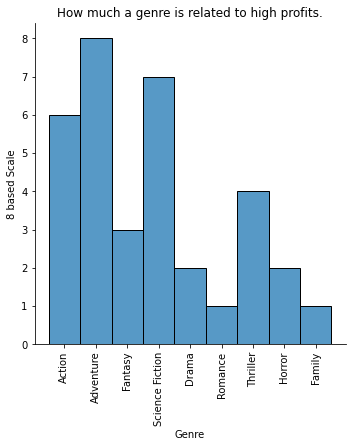

```python
pvgf(rrdf['genres'],"", "How much a genre is related to high profits.", "Genre", "8 based Scale")
```

### The most profit making genre appears to be one of the most popular also, it's adventure, then comes sci-fi and action as well.

## The most profit making directors.

**In individual movies**

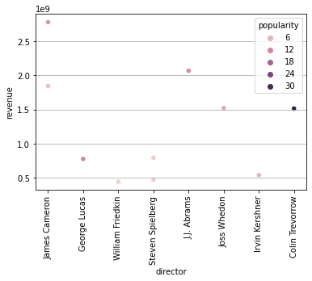

```python
sns.scatterplot(x= 'director', y= 'revenue', data= rrdf, hue= 'popularity');
plt.xticks(rotation=90);
plt.grid(axis= 'y');
```

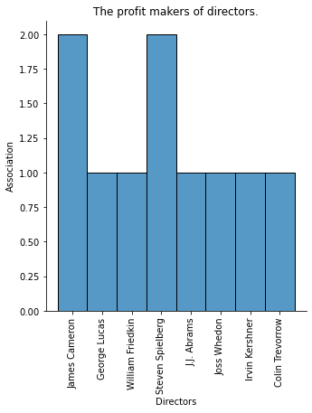

```python
pvgf(rrdf['director'].head(10),"", "The profit makers of directors.", "Directors", "Association");
```

## Frequently used keywords that describes high revenue movies.

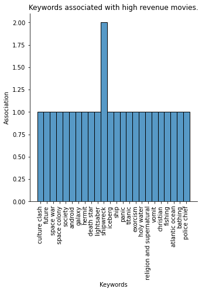

```python
pvgf(rrdf['keywords'].head(5),"", "Keywords associated with high revenue movies.", "Keywords", "Association");
```

### Shipwreck seems to be the most frequent

## The most profit making production companies.

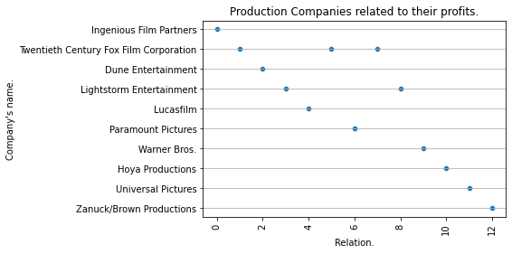

```python
pvgf(rrdf['production_companies'].head(5),"scatter", "Production Companies related to their profits.", "Relation.", "Company's name.");
plt.grid(axis='y')
```

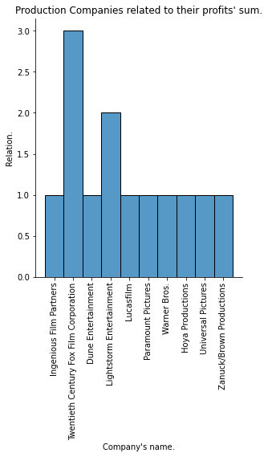

```python
pvgf(rrdf['production_companies'].head(5),"", "Production Companies related to their profits' sum.", "Company's name.", "Relation.");
```

### 20th Century Fox productions and Lightstorm Entertainment seems to be the most profit makers

## A heatmap to view the different corelations between the properties.

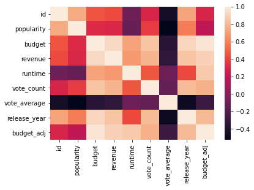

```python
sns.heatmap(rrdf.corr());
```

### As we see there's positive corelation between budget and each of revenue, release year, vote count and alittle with runtime. We see also that popularity isn't related much to almost any of the given properties.

## Conclusions:

*The key takeaways from this exploration are that a movie made by James Cameron and from the Adventure genre is likely to be a great success, especially if made by 20th century fox film company.*

**The used dataset is outdated, has no forign movies, and lost data, so it may be biased somehow.**